# CarbaSnake Summary Report

Output from CarbaSnake analysis pipeline

2025-07-16

**Results of run_20250713-112323**

[figure not shown]

CarbaSnake QC per Read Pair

Forward (R1) vs Reverse (R2) metrics side by side

|  | Reads (R1) | Reads (R2) | GC% (R1) | GC% (R2) | Dup% (R1) | Dup% (R2) | Per-base Q (R1) | Per-base Q (R2) | Per-seq Q (R1) | Per-seq Q (R2) | Base Content (R1) | Base Content (R2) | Seq GC (R1) | Seq GC (R2) | Base N (R1) | Base N (R2) | Dup Levels (R1) | Dup Levels (R2) | Adapter% (R1) | Adapter% (R2) | Overrep Seq (R1) | Overrep Seq (R2) | Read_R1 | Read_R2 |
| --- | --- | --- | --- | --- | --- | --- | --- | --- | --- | --- | --- | --- | --- | --- | --- | --- | --- | --- | --- | --- | --- | --- | --- | --- |
| ERR1830485 | 2.45M | 2.45M | 56.0% | 56.0% | 11.8% | 11.6% | pass | pass | pass | pass | pass | pass | warn | warn | pass | pass | pass | pass | pass | pass | pass | pass | R1 | R2 |
| ERR7221569 | 1.64M | 1.64M | 50.0% | 50.0% | 6.8% | 6.2% | pass | pass | pass | pass | pass | pass | warn | warn | pass | pass | pass | pass | pass | pass | pass | pass | R1 | R2 |
| ERR2124554 | 2.34M | 2.34M | 54.0% | 54.0% | 11.6% | 11.5% | pass | pass | pass | pass | warn | warn | warn | warn | pass | pass | pass | pass | pass | pass | pass | pass | R1 | R2 |
| ERR7221366 | 2.33M | 2.33M | 54.0% | 54.0% | 15.9% | 15.2% | pass | pass | pass | pass | pass | pass | warn | warn | pass | pass | pass | pass | pass | pass | pass | pass | R1 | R2 |
| ERR7221529 | 2.27M | 2.27M | 49.0% | 49.0% | 7.7% | 7.2% | pass | pass | pass | pass | pass | pass | fail | fail | pass | pass | pass | pass | pass | pass | pass | pass | R1 | R2 |
| ERR7221388 | 2.24M | 2.24M | 55.0% | 55.0% | 11.2% | 10.6% | pass | pass | pass | pass | pass | pass | warn | warn | pass | pass | pass | pass | pass | pass | pass | pass | R1 | R2 |
| ERR7221526 | 1.90M | 1.90M | 50.0% | 50.0% | 7.4% | 6.8% | pass | pass | pass | pass | pass | pass | warn | warn | pass | pass | pass | pass | pass | pass | pass | pass | R1 | R2 |
| ERR7221409 | 2.30M | 2.30M | 54.0% | 54.0% | 10.7% | 10.2% | pass | pass | pass | pass | pass | pass | warn | warn | pass | pass | pass | pass | pass | pass | pass | pass | R1 | R2 |
| ERR7221571 | 1.78M | 1.78M | 50.0% | 50.0% | 7.8% | 7.2% | pass | pass | pass | pass | pass | pass | warn | warn | pass | pass | pass | pass | pass | pass | pass | pass | R1 | R2 |
| ERR7221601 | 1.82M | 1.82M | 50.0% | 50.0% | 8.0% | 7.4% | pass | pass | pass | pass | pass | pass | warn | warn | pass | pass | pass | pass | pass | pass | pass | pass | R1 | R2 |
| ERR3143163 | 2.36M | 2.36M | 51.0% | 51.0% | 9.4% | 8.8% | pass | pass | pass | pass | pass | pass | warn | warn | pass | pass | pass | pass | pass | pass | pass | pass | R1 | R2 |
| ERR7221481 | 2.17M | 2.17M | 50.0% | 50.0% | 8.0% | 7.3% | pass | pass | pass | pass | pass | pass | warn | warn | pass | pass | pass | pass | pass | pass | pass | pass | R1 | R2 |
| ERR7221572 | 2.03M | 2.03M | 50.0% | 50.0% | 8.2% | 7.6% | pass | pass | pass | pass | pass | pass | warn | warn | pass | pass | pass | pass | pass | pass | pass | pass | R1 | R2 |
| ERR7221424 | 2.18M | 2.18M | 55.0% | 55.0% | 10.3% | 9.9% | pass | pass | pass | pass | pass | pass | warn | warn | pass | pass | pass | pass | pass | pass | pass | pass | R1 | R2 |
| ERR1837599 | 3.13M | 3.13M | 50.0% | 50.0% | 15.2% | 14.8% | pass | pass | pass | pass | pass | pass | warn | warn | pass | pass | pass | pass | pass | pass | pass | pass | R1 | R2 |
| ERR3143176 | 2.07M | 2.07M | 53.0% | 52.0% | 7.6% | 7.0% | pass | pass | pass | pass | pass | pass | warn | warn | pass | pass | pass | pass | pass | pass | pass | pass | R1 | R2 |
| ERR7221576 | 1.65M | 1.65M | 50.0% | 50.0% | 6.4% | 5.9% | pass | pass | pass | pass | pass | pass | warn | warn | pass | pass | pass | pass | pass | pass | pass | pass | R1 | R2 |
| ERR7221414 | 2.79M | 2.79M | 54.0% | 54.0% | 13.6% | 13.0% | pass | pass | pass | pass | pass | pass | warn | warn | pass | pass | pass | pass | pass | pass | pass | pass | R1 | R2 |
| ERR7221380 | 2.29M | 2.29M | 55.0% | 55.0% | 11.0% | 10.5% | pass | pass | pass | pass | pass | pass | warn | warn | pass | pass | pass | pass | pass | pass | pass | pass | R1 | R2 |
| ERR7221600 | 1.74M | 1.74M | 50.0% | 50.0% | 7.1% | 6.3% | pass | pass | pass | pass | pass | pass | warn | warn | pass | pass | pass | pass | pass | pass | pass | pass | R1 | R2 |
| ERR7221516 | 2.07M | 2.07M | 50.0% | 50.0% | 8.3% | 7.7% | pass | pass | pass | pass | pass | pass | warn | warn | pass | pass | pass | pass | pass | pass | pass | pass | R1 | R2 |
| ERR7221446 | 2.06M | 2.06M | 54.0% | 54.0% | 10.1% | 9.7% | pass | pass | pass | pass | pass | pass | warn | warn | pass | pass | pass | pass | pass | pass | pass | pass | R1 | R2 |
| ERR7221561 | 1.78M | 1.78M | 50.0% | 50.0% | 7.5% | 6.9% | pass | pass | pass | pass | pass | pass | warn | warn | pass | pass | pass | pass | pass | pass | pass | pass | R1 | R2 |
| ERR7221605 | 2.01M | 2.01M | 50.0% | 50.0% | 8.6% | 8.0% | pass | pass | pass | pass | pass | pass | warn | warn | pass | pass | pass | pass | pass | pass | pass | pass | R1 | R2 |
| ERR3143165 | 2.37M | 2.37M | 51.0% | 51.0% | 8.5% | 7.9% | pass | pass | pass | pass | pass | pass | warn | warn | pass | pass | pass | pass | pass | pass | pass | pass | R1 | R2 |
| ERR7221430 | 2.23M | 2.23M | 55.0% | 55.0% | 10.7% | 10.2% | pass | pass | pass | pass | pass | pass | warn | warn | pass | pass | pass | pass | pass | pass | pass | pass | R1 | R2 |
| ERR7221410 | 1.85M | 1.85M | 55.0% | 55.0% | 9.5% | 8.8% | pass | pass | pass | pass | pass | pass | warn | warn | pass | pass | pass | pass | pass | pass | pass | pass | R1 | R2 |
| ERR7221216 | 2.25M | 2.25M | 56.0% | 56.0% | 8.6% | 7.7% | pass | pass | pass | pass | pass | pass | warn | warn | pass | pass | pass | pass | pass | pass | pass | pass | R1 | R2 |
| ERR2107335 | 2.77M | 2.77M | 54.0% | 54.0% | 14.4% | 14.3% | pass | pass | pass | pass | warn | warn | warn | warn | pass | pass | pass | pass | pass | pass | pass | pass | R1 | R2 |
| ERR3143155 | 2.25M | 2.25M | 52.0% | 51.0% | 8.6% | 8.0% | pass | pass | pass | pass | pass | pass | warn | warn | pass | pass | pass | pass | pass | pass | pass | pass | R1 | R2 |

[output cut: 66 more lines]

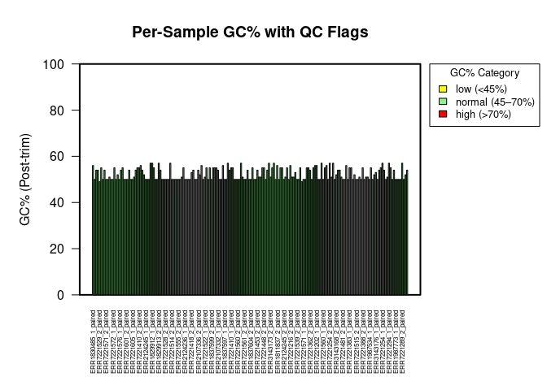

Coverage QC Summary

| sample | coverage | status |
| --- | --- | --- |
| ERR1811837 | 134.99 | PASS |
| ERR1829912 | 125.48 | PASS |
| ERR1829913 | 129.84 | PASS |
| ERR1830485 | 119.43 | PASS |
| ERR1837597 | 169.80 | PASS |
| ERR1837599 | 173.93 | PASS |
| ERR1837603 | 163.14 | PASS |
| ERR1837604 | 152.35 | PASS |
| ERR1981377 | 132.97 | PASS |
| ERR1981602 | 135.19 | PASS |
| ERR1987534 | 159.10 | PASS |
| ERR1987773 | 141.62 | PASS |
| ERR1990256 | 168.77 | PASS |
| ERR2106615 | 118.21 | PASS |
| ERR2107332 | 106.03 | PASS |
| ERR2107335 | 134.40 | PASS |
| ERR2107336 | 119.13 | PASS |
| ERR2107338 | 119.85 | PASS |
| ERR2124227 | 155.09 | PASS |
| ERR2124236 | 107.73 | PASS |
| ERR2124238 | 117.58 | PASS |
| ERR2124245 | 100.47 | PASS |
| ERR2124252 | 106.86 | PASS |
| ERR2124554 | 115.80 | PASS |
| ERR2124558 | 98.88 | PASS |
| ERR3143120 | 114.85 | PASS |
| ERR3143149 | 116.10 | PASS |
| ERR3143154 | 110.15 | PASS |
| ERR3143155 | 110.99 | PASS |
| ERR3143163 | 124.92 | PASS |

[output cut: 66 more lines]

Kraken2 Top Taxa

Highest-abundance Order (O), Genus (G) & Species (S)

|  | Order (O) | Genus (G) | Species (S) |
| --- | --- | --- | --- |
| ERR1811837 | Enterobacterales | Klebsiella | Klebsiella pneumoniae |
| ERR1829912 | Enterobacterales | Klebsiella | Klebsiella pneumoniae |
| ERR1829913 | Enterobacterales | Klebsiella | Klebsiella pneumoniae |
| ERR1830485 | Enterobacterales | Klebsiella | Klebsiella pneumoniae |
| ERR1837597 | Enterobacterales | Escherichia | Escherichia coli |
| ERR1837599 | Enterobacterales | Escherichia | Escherichia coli |
| ERR1837603 | Enterobacterales | Escherichia | Escherichia coli |
| ERR1837604 | Enterobacterales | Escherichia | Escherichia coli |
| ERR1981377 | Enterobacterales | Escherichia | Escherichia coli |
| ERR1981602 | Enterobacterales | Escherichia | Escherichia coli |
| ERR1987534 | Enterobacterales | Escherichia | Escherichia coli |
| ERR1987773 | Enterobacterales | Escherichia | Escherichia coli |
| ERR1990256 | Enterobacterales | Escherichia | Escherichia marmotae |
| ERR2106615 | Enterobacterales | Klebsiella | Klebsiella pneumoniae |
| ERR2107332 | Enterobacterales | Enterobacter | Enterobacter cloacae |
| ERR2107335 | Enterobacterales | Enterobacter | Enterobacter cloacae |
| ERR2107336 | Enterobacterales | Enterobacter | Enterobacter cloacae |
| ERR2107338 | Enterobacterales | Enterobacter | Enterobacter hormaechei |
| ERR2124227 | Enterobacterales | Escherichia | Escherichia coli |
| ERR2124236 | Enterobacterales | Escherichia | Escherichia coli |
| ERR2124238 | Enterobacterales | Escherichia | Escherichia coli |
| ERR2124245 | Enterobacterales | Escherichia | Escherichia coli |
| ERR2124252 | Enterobacterales | Escherichia | Escherichia coli |
| ERR2124554 | Enterobacterales | Enterobacter | Enterobacter cloacae |
| ERR2124558 | Enterobacterales | Enterobacter | Enterobacter cloacae |
| ERR3143120 | Enterobacterales | Citrobacter | Citrobacter freundii |
| ERR3143149 | Enterobacterales | Citrobacter | Citrobacter sp. FDAARGOS_156 |
| ERR3143154 | Enterobacterales | Citrobacter | Citrobacter sp. FDAARGOS_156 |
| ERR3143155 | Enterobacterales | Citrobacter | Citrobacter freundii |
| ERR3143163 | Enterobacterales | Citrobacter | Citrobacter freundii |

[output cut: 66 more lines]

Names only — no percentages displayed.

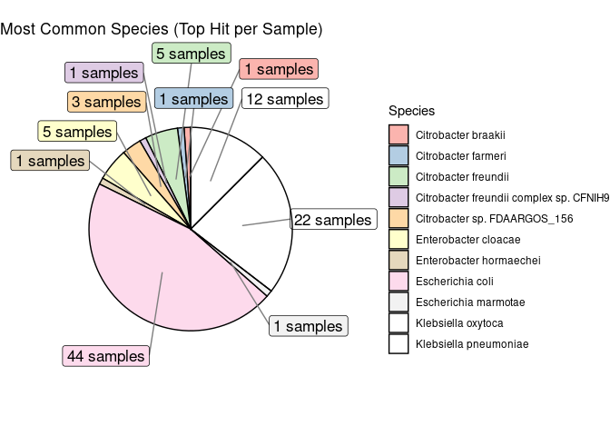

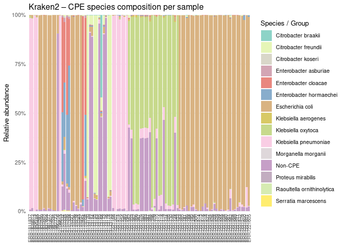

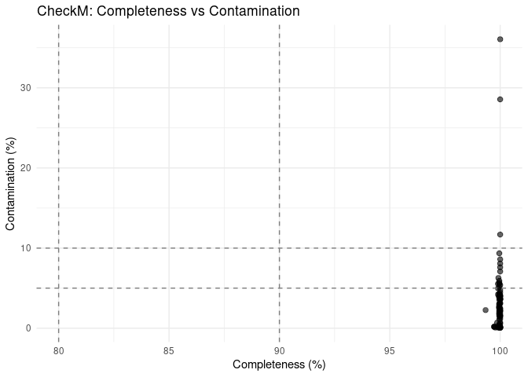

CheckM Results

Completeness, contamination & strain heterogeneity

|  | Sample | Completeness % | Contamination % | Strain het % |
| --- | --- | --- | --- | --- |
| ERR1811837 | ERR1811837 | 100.0 | 0.1 | 0.0 |
| ERR1829912 | ERR1829912 | 100.0 | 0.2 | 0.0 |
| ERR1829913 | ERR1829913 | 100.0 | 0.1 | 0.0 |
| ERR1830485 | ERR1830485 | 100.0 | 0.2 | 0.0 |
| ERR1990256 | ERR1990256 | 100.0 | 0.1 | 0.0 |
| ERR2106615 | ERR2106615 | 100.0 | 0.1 | 0.0 |
| ERR2124236 | ERR2124236 | 100.0 | 0.1 | 0.0 |
| ERR3143120 | ERR3143120 | 100.0 | 1.6 | 66.7 |
| ERR3143155 | ERR3143155 | 100.0 | 2.4 | 56.5 |
| ERR3143163 | ERR3143163 | 100.0 | 3.1 | 65.4 |
| ERR3143193 | ERR3143193 | 100.0 | 2.2 | 83.3 |
| ERR7221168 | ERR7221168 | 100.0 | 3.6 | 54.4 |
| ERR7221202 | ERR7221202 | 100.0 | 0.7 | 0.0 |
| ERR7221214 | ERR7221214 | 100.0 | 1.2 | 0.0 |
| ERR7221216 | ERR7221216 | 100.0 | 0.6 | 42.9 |
| ERR7221254 | ERR7221254 | 100.0 | 1.4 | 46.1 |
| ERR7221289 | ERR7221289 | 100.0 | 1.5 | 36.4 |
| ERR7221294 | ERR7221294 | 100.0 | 1.6 | 0.0 |
| ERR7221352 | ERR7221352 | 100.0 | 3.7 | 55.6 |
| ERR7221353 | ERR7221353 | 100.0 | 2.5 | 69.2 |
| ERR7221362 | ERR7221362 | 100.0 | 2.1 | 52.6 |
| ERR7221366 | ERR7221366 | 100.0 | 2.2 | 48.0 |
| ERR7221367 | ERR7221367 | 100.0 | 3.1 | 42.4 |
| ERR7221376 | ERR7221376 | 100.0 | 3.7 | 65.0 |
| ERR7221380 | ERR7221380 | 100.0 | 3.6 | 51.6 |
| ERR7221383 | ERR7221383 | 100.0 | 4.0 | 63.2 |
| ERR7221387 | ERR7221387 | 100.0 | 4.0 | 59.1 |
| ERR7221388 | ERR7221388 | 100.0 | 4.0 | 54.5 |
| ERR7221396 | ERR7221396 | 100.0 | 4.7 | 51.2 |
| ERR7221409 | ERR7221409 | 100.0 | 4.1 | 47.8 |

[output cut: 66 more lines]

Metrics parsed from each sample’s **checkm_summary.tsv**.

AMRFinder-Plus Per-sample Profile

AMR gene count, symbols, and resistance classes

|  | Gene count | Gene symbols | Drug classes |
| --- | --- | --- | --- |
| ERR1811837.amrfinder | 5 | blaKPC-2, blaOXA, blaSHV-36, blaTEM-1, fosA10 | BETA-LACTAM, FOSFOMYCIN |
| ERR1829912.amrfinder | 4 | blaKPC-2, blaSHV-40, blaTEM-1, fosA10 | BETA-LACTAM, FOSFOMYCIN |
| ERR1829913.amrfinder | 14 | aac(6')-Ib, aadA2, aph(3')-Ia, blaKPC-3, blaOXA, blaSHV-11, blaTEM, catA1, dfrA12, fosA, mph(A), oqxA, oqxB, sul1 | AMINOGLYCOSIDE, BETA-LACTAM, FOSFOMYCIN, MACROLIDE, PHENICOL, PHENICOL/QUINOLONE, SULFONAMIDE, TRIMETHOPRIM |
| ERR1830485.amrfinder | 11 | aph(3'')-Ib, aph(6)-Id, blaOXA-48, blaSHV-11, blaTEM-1, dfrA14, fosA5, oqxA, oqxB, sul2, tet(D) | AMINOGLYCOSIDE, BETA-LACTAM, FOSFOMYCIN, PHENICOL/QUINOLONE, SULFONAMIDE, TETRACYCLINE, TRIMETHOPRIM |
| ERR1837597.amrfinder | 15 | aadA1, aadA5, aph(3'')-Ib, aph(6)-Id, blaKPC-2, blaOXA, blaTEM-1, catA1, dfrA1, dfrA17, dfrA36, floR, sul1, sul2, tet(B) | AMINOGLYCOSIDE, BETA-LACTAM, PHENICOL, SULFONAMIDE, TETRACYCLINE, TRIMETHOPRIM |
| ERR1837599.amrfinder | 9 | aadA1, aph(3'')-Ib, aph(6)-Id, blaOXA-48, dfrA1, floR, sat2, sul2, tet(A) | AMINOGLYCOSIDE, BETA-LACTAM, PHENICOL, STREPTOTHRICIN, SULFONAMIDE, TETRACYCLINE, TRIMETHOPRIM |
| ERR1837603.amrfinder | 1 | blaOXA-48 | BETA-LACTAM |
| ERR1837604.amrfinder | 8 | aac(3)-IId, aadA5, blaCTX-M-24, blaOXA-48, blaTEM-1, dfrA17, mph(A), sul1 | AMINOGLYCOSIDE, BETA-LACTAM, MACROLIDE, SULFONAMIDE, TRIMETHOPRIM |
| ERR1981377.amrfinder | 12 | aadA2, aadA5, blaCMY-42, blaNDM-5, blaTEM-1, ble, dfrA12, dfrA17, mph(A), rmtB1, sul1, tet(A) | AMINOGLYCOSIDE, BETA-LACTAM, BLEOMYCIN, MACROLIDE, SULFONAMIDE, TETRACYCLINE, TRIMETHOPRIM |
| ERR1981602.amrfinder | 6 | blaDHA-1, blaOXA-48, dfrA17, mph(A), qnrB4, sul1 | BETA-LACTAM, MACROLIDE, QUINOLONE, SULFONAMIDE, TRIMETHOPRIM |
| ERR1987534.amrfinder | 1 | blaOXA-48 | BETA-LACTAM |
| ERR1987773.amrfinder | 2 | blaOXA-48, blaTEM-1 | BETA-LACTAM |
| ERR1990256.amrfinder | 1 | blaOXA-48 | BETA-LACTAM |
| ERR2106615.amrfinder | 13 | aac(6')-Ib, aadA2, blaKPC-3, blaOXA, blaSHV-11, blaTEM, catA1, dfrA12, fosA, mph(A), oqxA, oqxB, sul1 | AMINOGLYCOSIDE, BETA-LACTAM, FOSFOMYCIN, MACROLIDE, PHENICOL, PHENICOL/QUINOLONE, SULFONAMIDE, TRIMETHOPRIM |
| ERR2107332.amrfinder | 19 | aac(3)- IIe, aac(6')-Ib-cr5, aadA1, aph(3'')-Ib, aph(6)-Id, blaACT-45, blaCTX-M-15, blaOXA-1, blaOXA-48, blaTEM, catA1, catB3, dfrA14, fosA, oqxA, oqxB, qnrB1, sul2, tet(A) | AMINOGLYCOSIDE, AMINOGLYCOSIDE/QUINOLONE, BETA-LACTAM, FOSFOMYCIN, PHENICOL, PHENICOL/QUINOLONE, QUINOLONE, SULFONAMIDE, TETRACYCLINE, TRIMETHOPRIM |
| ERR2107335.amrfinder | 11 | aac(6')-Ib', aadA2, ant(2'')-Ia, blaACT-55, blaCTX-M-9, blaVIM-1, dfrA16, oqxA, oqxB, qnrA1, sul1 | AMINOGLYCOSIDE, BETA-LACTAM, PHENICOL/QUINOLONE, QUINOLONE, SULFONAMIDE, TRIMETHOPRIM |
| ERR2107336.amrfinder | 19 | aac(3)- IIe, aac(6')-Ib-cr5, aadA1, aph(3'')-Ib, aph(6)-Id, blaACT-45, blaCTX-M-15, blaOXA-1, blaOXA-48, blaTEM, catA1, catB3, dfrA14, fosA, oqxA, oqxB, qnrB1, sul2, tet(A) | AMINOGLYCOSIDE, AMINOGLYCOSIDE/QUINOLONE, BETA-LACTAM, FOSFOMYCIN, PHENICOL, PHENICOL/QUINOLONE, QUINOLONE, SULFONAMIDE, TETRACYCLINE, TRIMETHOPRIM |
| ERR2107338.amrfinder | 10 | aac(3)-IId, aac(6')-Ib', blaACT, blaTEM-1, blaVIM-1, fosA, oqxA, oqxB, qnrS1, sul1 | AMINOGLYCOSIDE, BETA-LACTAM, FOSFOMYCIN, PHENICOL/QUINOLONE, QUINOLONE, SULFONAMIDE |
| ERR2124227.amrfinder | 1 | blaOXA-48 | BETA-LACTAM |
| ERR2124236.amrfinder | 7 | aadA2, blaOXA-48, blaTEM-1, dfrA12, sul1, sul3, tet(A) | AMINOGLYCOSIDE, BETA-LACTAM, SULFONAMIDE, TETRACYCLINE, TRIMETHOPRIM |
| ERR2124238.amrfinder | 6 | aph(3'')-Ib, aph(6)-Id, blaOXA-48, blaTEM-1, dfrA14, sul2 | AMINOGLYCOSIDE, BETA-LACTAM, SULFONAMIDE, TRIMETHOPRIM |
| ERR2124245.amrfinder | 1 | blaOXA-48 | BETA-LACTAM |
| ERR2124252.amrfinder | 2 | blaOXA-48, tet(B) | BETA-LACTAM, TETRACYCLINE |
| ERR2124554.amrfinder | 11 | aac(3)-IIe, aac(6')-Ib', blaACT-24, blaCTX-M-15, blaVIM-1, dfrA14, fosA, oqxA, oqxB, sul1, tet(A) | AMINOGLYCOSIDE, BETA-LACTAM, FOSFOMYCIN, PHENICOL/QUINOLONE, SULFONAMIDE, TETRACYCLINE, TRIMETHOPRIM |
| ERR2124558.amrfinder | 14 | aac(6')-Ib', aph(3'')-Ib, aph(6)-Id, blaACT-16, blaSHV-12, blaTEM-1, blaVIM-1, dfrA19, fosA, oqxA, oqxB, qnrA1, sul1, tet(D) | AMINOGLYCOSIDE, BETA-LACTAM, FOSFOMYCIN, PHENICOL/QUINOLONE, QUINOLONE, SULFONAMIDE, TETRACYCLINE, TRIMETHOPRIM |
| ERR3143120.amrfinder | 6 | aac(6')-Ib-cr, aac(6')-If, blaCMY, blaOXA-48, qnrB, sat2 | AMINOGLYCOSIDE, AMINOGLYCOSIDE/QUINOLONE, BETA-LACTAM, QUINOLONE, STREPTOTHRICIN |
| ERR3143149.amrfinder | 12 | aac(6')-Ib-cr5, ant(2'')-Ia, arr-3, blaCMY, blaDHA-1, blaKPC-2, blaOXA-1, blaTEM-1, catB3, mph(A), qnrB4, sul1 | AMINOGLYCOSIDE, AMINOGLYCOSIDE/QUINOLONE, BETA-LACTAM, MACROLIDE, PHENICOL, QUINOLONE, RIFAMYCIN, SULFONAMIDE |
| ERR3143154.amrfinder | 10 | aac(6')-Ib-cr5, arr-3, blaCMY, blaDHA-1, blaKPC-2, blaOXA-1, catB3, mph(A), qnrB4, sul1 | AMINOGLYCOSIDE/QUINOLONE, BETA-LACTAM, MACROLIDE, PHENICOL, QUINOLONE, RIFAMYCIN, SULFONAMIDE |
| ERR3143155.amrfinder | 13 | aac(3)-IId, aadA1, aadA2, blaCMY-48, blaOXA-48, blaTEM-1, dfrA1, dfrA12, mph(A), sat2, sul1, sul2, tet(D) | AMINOGLYCOSIDE, BETA-LACTAM, MACROLIDE, STREPTOTHRICIN, SULFONAMIDE, TETRACYCLINE, TRIMETHOPRIM |
| ERR3143163.amrfinder | 3 | blaCMY-180, blaOXA-48, qnrB38 | BETA-LACTAM, QUINOLONE |

[output cut: 66 more lines]

Parsed from AMRFinder-Plus TSV outputs — duplicates removed.

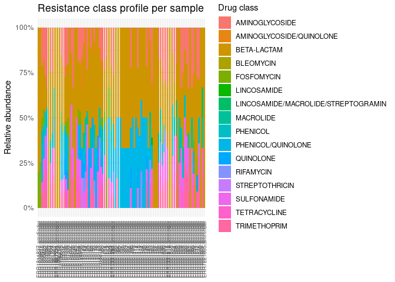

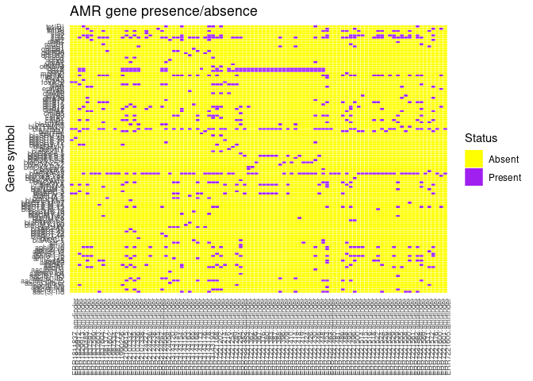

[output not shown]

VFDB Hits

Virulence gene count, symbols, and product descriptions

|  | Gene count | Gene symbols | Products |
| --- | --- | --- | --- |
| ERR1811837 | 10 | entA, entB, fepC, ompA, yagV/ecpE, yagW/ecpD, yagX/ecpC, yagY/ecpB, yagZ/ecpA, ykgK/ecpR | **ompA** – (ompA) outer membrane protein A [OmpA (VF0236)] [Escherichia coli O18:K1:H7 str. RS218] **fepC** – (fepC) ferrienterobactin ABC transporter ATPase [Enterobactin (VF0228)] [Escherichia coli … |
| ERR1829912 | 10 | entA, entB, fepC, ompA, yagV/ecpE, yagW/ecpD, yagX/ecpC, yagY/ecpB, yagZ/ecpA, ykgK/ecpR | **yagV/ecpE** – (yagV/ecpE) E. coli common pilus chaperone EcpE [ECP (VF0404)] [Escherichia coli O157:H7 str. EDL933] **yagW/ecpD** – (yagW/ecpD) polymerized tip adhesin of ECP fibers [ECP (VF0404)] [… |
| ERR1829913 | 10 | entA, entB, fepC, ompA, yagV/ecpE, yagW/ecpD, yagX/ecpC, yagY/ecpB, yagZ/ecpA, ykgK/ecpR | **yagV/ecpE** – (yagV/ecpE) E. coli common pilus chaperone EcpE [ECP (VF0404)] [Escherichia coli O157:H7 str. EDL933] **yagW/ecpD** – (yagW/ecpD) polymerized tip adhesin of ECP fibers [ECP (VF0404)] [… |
| ERR1830485 | 11 | entA, entB, fepC, fepG, ompA, yagV/ecpE, yagW/ecpD, yagX/ecpC, yagY/ecpB, yagZ/ecpA, ykgK/ecpR | **ompA** – (ompA) outer membrane protein A [OmpA (VF0236)] [Escherichia coli O18:K1:H7 str. RS218] **entA** – (entA) 23-dihydro-23-dihydroxybenzoate dehydrogenase [Enterobactin (VF0228)] [Escherichia … |
| ERR1837597 | 78 | afaA- VIII, afaB-VIII, afaC-VIII, afaD-VIII, afaE-VIII, afaF-VII, astA, csgB, csgD, csgF, csgG, entA, entB, entC, entD, entE, entF, entS, espL1, espR1, espX1, espX4, espX5, fdeC, fepA, fepB, fepC, fep… | **fimH** – (fimH) FimH protein precursor [Type 1 fimbriae (VF0221)] [Escherichia coli CFT073] **fimG** – (fimG) FimG protein precursor [Type 1 fimbriae (VF0221)] [Escherichia coli CFT073] **fimF** – (… |
| ERR1837599 | 40 | csgB, csgD, csgF, csgG, entA, entB, entC, entD, entE, entF, entS, espL1, espR1, espX1, espX4, espX5, fdeC, fepA, fepB, fepC, fepD, fepG, fes, fimA, fimB, fimC, fimD, fimE, fimF, fimG, fimH, fimI, gspM… | **entA** – (entA) 23-dihydro-23-dihydroxybenzoate dehydrogenase [Enterobactin (VF0228)] [Escherichia coli CFT073] **entB** – (entB) isochorismatase [Enterobactin (VF0228)] [Escherichia coli CFT073] **… |
| ERR1837603 | 52 | astA, csgB, csgD, csgF, csgG, entA, entB, entC, entD, entE, entF, entS, espL1, espR1, espX1, espX4, espX5, fdeC, fepA, fepB, fepC, fepD, fepG, fes, fimA, fimB, fimC, fimD, fimE, fimF, fimG, fimH, fimI… | **espL1** – (espL1) Type III secretion system effector espL1 [LEE encoded T3SS (SS020)] [Escherichia coli O157:H7 str. EDL933] **csgG** – (csgG) curli production assembly/transport protein CsgG [Agf (… |
| ERR1837604 | 86 | afaA, afaB-I, afaC-I, afaE-V, aslA, chuS, chuU, chuV, chuW, chuY, csgB, csgD, csgF, csgG, daaF, draD, draP, entA, entB, entC, entD, entE, entF, entS, espL1, espL4, espR1, espR4, espX1, espX4, espX5, e… | **espL1** – (espL1) Type III secretion system effector espL1 [LEE encoded T3SS (SS020)] [Escherichia coli O157:H7 str. EDL933] **espY4** – (espY4) Type III secretion system effector EspY4 [LEE encoded… |
| ERR1981377 | 56 | aslA, csgB, csgD, csgF, csgG, entA, entB, entC, entD, entE, entF, entS, espL1, espL4, espR1, espR4, espX1, espX4, espX5, espY1, fdeC, fepA, fepB, fepC, fepD, fepG, fes, fyuA, gspC, gspD, gspE, gspF, g… | **entD** – (entD) phosphopantetheinyl transferase component of enterobactin synthase multienzyme complex [Enterobactin (VF0228)] [Escherichia coli CFT073] **fepA** – (fepA) ferrienterobactin outer mem… |
| ERR1981602 | 64 | afaD, afaF-III, csgB, csgD, csgF, csgG, draA, draB, draC, draP, entA, entB, entC, entD, entE, entF, entS, espL1, espR1, espX1, espX4, espX5, fdeC, fepA, fepB, fepC, fepD, fepG, fes, fimA, fimB, fimC, … | **fdeC** – (fdeC) adhesin FdeC [FdeC (VF0506)] [Escherichia coli O45:K1:H7 str. S88] **ykgK/ecpR** – (ykgK/ecpR) regulator protein EcpR [ECP (VF0404)] [Escherichia coli O157:H7 str. EDL933] **yagZ/ecp… |
| ERR1987534 | 72 | aslA, chuA, chuS, chuT, chuU, chuV, chuW, chuX, chuY, csgB, csgD, csgF, csgG, entA, entB, entC, entD, entE, entF, entS, fdeC, fepA, fepB, fepC, fepD, fepG, fes, fimA, fimB, fimC, fimD, fimE, fimF, fim… | **chuV** – (chuV) ATP-binding hydrophilic protein ChuV [Chu (VF0227)] [Escherichia coli CFT073] **chuU** – (chuU) heme permease protein ChuU [Chu (VF0227)] [Escherichia coli CFT073] **chuY** – (chuY) … |
| ERR1987773 | 70 | aslA, chuA, chuS, chuT, chuU, chuV, chuW, chuX, chuY, csgB, csgD, csgF, csgG, entA, entB, entC, entD, entE, entF, entS, fdeC, fepA, fepB, fepC, fepD, fepG, fes, fimA, fimB, fimC, fimD, fimE, fimF, fim… | **chuV** – (chuV) ATP-binding hydrophilic protein ChuV [Chu (VF0227)] [Escherichia coli CFT073] **chuU** – (chuU) heme permease protein ChuU [Chu (VF0227)] [Escherichia coli CFT073] **chuY** – (chuY) … |
| ERR1990256 | 62 | aslA, astA, chuS, chuT, chuU, chuV, chuW, chuX, csgB, csgD, csgE, csgF, csgG, entA, entB, entC, entD, entE, entF, entS, fepA, fepB, fepC, fepD, fepG, fes, fimA, fimB, fimC, fimD, fimE, fimF, fimG, fim… | **csgB** – (csgB) minor curlin subunit precursor curli nucleator protein CsgB [Agf (VF0103)] [Salmonella enterica subsp. enterica serovar Typhimurium str. LT2] **csgD** – (csgD) DNA-binding transcript… |
| ERR2106615 | 10 | entA, entB, fepC, ompA, yagV/ecpE, yagW/ecpD, yagX/ecpC, yagY/ecpB, yagZ/ecpA, ykgK/ecpR | **entA** – (entA) 23-dihydro-23-dihydroxybenzoate dehydrogenase [Enterobactin (VF0228)] [Escherichia coli CFT073] **entB** – (entB) isochorismatase [Enterobactin (VF0228)] [Escherichia coli CFT073] **… |
| ERR2107332 | 2 | entB, ompA | **entB** – (entB) isochorismatase [Enterobactin (VF0228)] [Escherichia coli CFT073] **ompA** – (ompA) outer membrane protein A [OmpA (VF0236)] [Escherichia coli O18:K1:H7 str. RS218] |
| ERR2107335 | 6 | csgG, entB, lpfA, lpfB, lpfC, ompA | **csgG** – (csgG) curli production assembly/transport protein CsgG [Agf (VF0103)] [Salmonella enterica subsp. enterica serovar Typhimurium str. LT2] **ompA** – (ompA) outer membrane protein A [OmpA (V… |
| ERR2107336 | 2 | entB, ompA | **entB** – (entB) isochorismatase [Enterobactin (VF0228)] [Escherichia coli CFT073] **ompA** – (ompA) outer membrane protein A [OmpA (VF0236)] [Escherichia coli O18:K1:H7 str. RS218] |
| ERR2107338 | 3 | csgG, entA, ompA | **ompA** – (ompA) outer membrane protein A [OmpA (VF0236)] [Escherichia coli O18:K1:H7 str. RS218] **csgG** – (csgG) curli production assembly/transport protein CsgG [Agf (VF0103)] [Salmonella enteric… |
| ERR2124227 | 68 | aslA, chuA, chuS, chuT, chuU, chuV, chuW, chuY, csgB, csgD, csgF, csgG, entA, entB, entC, entD, entE, entF, entS, espL1, espL4, espR1, espR3, espX1, espX2, espX4, espX5, espY1, espY2, espY3, espY4, fd… | **espY4** – (espY4) Type III secretion system effector EspY4 [LEE encoded T3SS (SS020)] [Escherichia coli O157:H7 str. EDL933] **entD** – (entD) phosphopantetheinyl transferase component of enterobact… |
| ERR2124236 | 62 | aslA, astA, csgB, csgD, csgF, csgG, entA, entB, entC, entD, entE, entF, entS, espL1, espL4, espR1, espX1, espX4, espX5, espY1, fdeC, fepA, fepB, fepC, fepD, fepG, fes, fimC, fimD, fimF, fimG, fimH, fi… | **entA** – (entA) 23-dihydro-23-dihydroxybenzoate dehydrogenase [Enterobactin (VF0228)] [Escherichia coli CFT073] **entB** – (entB) isochorismatase [Enterobactin (VF0228)] [Escherichia coli CFT073] **… |
| ERR2124238 | 50 | csgB, csgD, csgF, csgG, entA, entB, entC, entD, entE, entF, entS, espL1, espR1, espX1, espX4, espX5, fdeC, fepA, fepB, fepC, fepD, fepG, fes, fimA, fimB, fimC, fimD, fimE, fimF, fimG, fimH, fimI, gspC… | **espX5** – (espX5) Type III secretion system effector EspX5 [LEE encoded T3SS (SS020)] [Escherichia coli O157:H7 str. EDL933] **espX4** – (espX4) Type III secretion system effector EspX4 [LEE encoded… |
| ERR2124245 | 73 | aslA, chuA, chuS, chuT, chuU, chuV, chuW, chuX, chuY, csgB, csgD, csgF, csgG, entA, entB, entC, entD, entE, entF, entS, fdeC, fepA, fepB, fepC, fepD, fepG, fes, fimA, fimB, fimC, fimD, fimE, fimF, fim… | **fimB** – (fimB) Type 1 fimbriae Regulatory protein fimB [Type 1 fimbriae (VF0221)] [Escherichia coli CFT073] **fimE** – (fimE) Type 1 fimbriae Regulatory protein fimE [Type 1 fimbriae (VF0221)] [Esc… |
| ERR2124252 | 48 | csgB, csgD, csgF, csgG, entA, entB, entC, entD, entE, entF, entS, espR1, espX1, espX5, fdeC, fepA, fepB, fepC, fepD, fepG, fes, fimA, fimB, fimC, fimD, fimE, fimF, fimG, fimH, fimI, gspC, gspD, gspE, … | **ompA** – (ompA) outer membrane protein A [OmpA (VF0236)] [Escherichia coli O18:K1:H7 str. RS218] **espX5** – (espX5) Type III secretion system effector EspX5 [LEE encoded T3SS (SS020)] [Escherichia … |
| ERR2124554 | 3 | csgG, entA, ompA | **ompA** – (ompA) outer membrane protein A [OmpA (VF0236)] [Escherichia coli O18:K1:H7 str. RS218] **csgG** – (csgG) curli production assembly/transport protein CsgG [Agf (VF0103)] [Salmonella enteric… |
| ERR2124558 | 2 | entB, ompA | **entB** – (entB) isochorismatase [Enterobactin (VF0228)] [Escherichia coli CFT073] **ompA** – (ompA) outer membrane protein A [OmpA (VF0236)] [Escherichia coli O18:K1:H7 str. RS218] |
| ERR3143120 | 11 | chuX, csgB, csgD, csgE, csgF, csgG, entB, entE, fepC, fliG, ompA | **csgG** – (csgG) curli production assembly/transport protein CsgG [Agf (VF0103)] [Salmonella enterica subsp. enterica serovar Typhimurium str. LT2] **csgF** – (csgF) curli production assembly/transpo… |
| ERR3143149 | 8 | chuX, csgB, csgD, csgE, csgF, csgG, fliG, ompA | **chuX** – (chuX) putative heme-binding protein ChuX [Chu (VF0227)] [Escherichia coli CFT073] **fliG** – (fliG) flagellar motor switch protein G [Flagella (VF0394)] [Yersinia enterocolitica subsp. ent… |
| ERR3143154 | 8 | chuX, csgB, csgD, csgE, csgF, csgG, fliG, ompA | **chuX** – (chuX) putative heme-binding protein ChuX [Chu (VF0227)] [Escherichia coli CFT073] **csgG** – (csgG) curli production assembly/transport protein CsgG [Agf (VF0103)] [Salmonella enterica sub… |
| ERR3143155 | 12 | chuX, csgB, csgD, csgE, csgF, csgG, entB, entE, entS, fepC, fliG, ompA | **ompA** – (ompA) outer membrane protein A [OmpA (VF0236)] [Escherichia coli O18:K1:H7 str. RS218] **entB** – (entB) isochorismatase [Enterobactin (VF0228)] [Escherichia coli CFT073] **entE** – (entE)… |
| ERR3143163 | 11 | chuX, csgB, csgD, csgE, csgF, csgG, entB, entE, fepC, fliG, ompA | **chuX** – (chuX) putative heme-binding protein ChuX [Chu (VF0227)] [Escherichia coli CFT073] **fepC** – (fepC) ferrienterobactin ABC transporter ATPase [Enterobactin (VF0228)] [Escherichia coli CFT07… |

[output cut: 66 more lines]

Parsed from VFDB TSV outputs.

[figure not shown]

PlasmidFinder Per-sample Summary

Replicon count and names

|  | Replicon count | Replicon names |
| --- | --- | --- |
| ERR1811837 | 4 | Col440I_1, IncFIA(HI1)_1_HI1, IncFIB(pQil)_1_pQil, IncFII_1_pKP91 |
| ERR1829912 | 3 | IncFIB(K)_1_Kpn3, IncR_1, pENTAS02_1 |
| ERR1829913 | 4 | ColRNAI_1, IncFIB(K)_1_Kpn3, IncFIB(pQil)_1_pQil, IncFII_1_pKP91 |
| ERR1830485 | 6 | Col440I_1, Col440II_1, ColRNAI_1, IncFIB(K)_1_Kpn3, IncFII_1_pKP91, IncL/M(pOXA-48)_1_pOXA-48 |
| ERR1837597 | 4 | IncFIB(AP001918)_1, IncFIB(pQil)_1_pQil, IncFIC(FII)_1, IncFII_1_pKP91 |
| ERR1837599 | 4 | IncB/O/K/Z_2, IncFIA_1, IncFIB(AP001918)_1, IncL/M(pOXA-48)_1_pOXA-48 |
| ERR1837603 | 4 | Col156_1, IncFIB(AP001918)_1, IncL/M(pOXA-48)_1_pOXA-48, IncY_1 |
| ERR1981377 | 5 | Col440I_1, ColRNAI_1, IncFIA_1, IncFIC(FII)_1, IncI_Gamma_1 |
| ERR1981602 | 4 | Col156_1, ColRNAI_1, IncFIA_1, IncFIB(AP001918)_1 |
| ERR1987534 | 2 | ColRNAI_1, IncL/M(pOXA-48)_1_pOXA-48 |
| ERR1987773 | 3 | IncFIB(AP001918)_1, IncFII_1, IncL/M(pOXA-48)_1_pOXA-48 |
| ERR1990256 | 1 | IncL/M(pOXA-48)_1_pOXA-48 |
| ERR2106615 | 3 | ColRNAI_1, IncFIB(pQil)_1_pQil, IncFII_1_pKP91 |
| ERR2107332 | 5 | ColRNAI_1, IncHI2_1, IncHI2A_1, IncL/M(pOXA-48)_1_pOXA-48, RepA_1_pKPC-CAV1321 |
| ERR2107335 | 8 | Col440I_1, Col440II_1, ColRNAI_1, IncFIB(pECLA)_1_pECLA, IncFII(pECLA)_1_pECLA, IncHI2_1, IncHI2A_1, RepA_1_pKPC-CAV1321 |
| ERR2107336 | 5 | ColRNAI_1, IncHI2_1, IncHI2A_1, IncL/M(pOXA-48)_1_pOXA-48, RepA_1_pKPC-CAV1321 |
| ERR2107338 | 6 | Col440II_1, ColRNAI_1, IncFII(pCRY)_1_pCRY, IncHI2_1, IncHI2A_1, RepA_1_pKPC-CAV1321 |
| ERR2124227 | 1 | IncL/M(pOXA-48)_1_pOXA-48 |
| ERR2124236 | 4 | ColRNAI_1, IncL/M(pOXA-48)_1_pOXA-48, IncR_1, IncX1_1 |
| ERR2124238 | 4 | IncB/O/K/Z_2, IncFII_1, IncI2_1_Delta, IncL/M(pOXA-48)_1_pOXA-48 |
| ERR2124245 | 3 | ColRNAI_1, IncFII(29)_1_pUTI89, IncL/M(pOXA-48)_1_pOXA-48 |
| ERR2124252 | 4 | IncI1_1_Alpha, IncL/M(pOXA-48)_1_pOXA-48, IncX1_1, IncX3_1 |
| ERR2124554 | 6 | ColRNAI_1, IncFIB(K)_1_Kpn3, IncFII(Yp)_1_Yersenia, IncHI2_1, IncHI2A_1, RepA_1_pKPC-CAV1321 |
| ERR2124558 | 3 | IncHI2_1, IncHI2A_1, RepA_1_pKPC-CAV1321 |
| ERR3143120 | 6 | Col(IMGS31)_1, Col440I_1, ColRNAI_1, IncFII(p14)_1_p14, IncL/M(pOXA-48)_1_pOXA-48, IncX1_1 |
| ERR3143149 | 10 | Col(IMGS31)_1, Col156_1, Col440I_1, Col8282_1, ColRNAI_1, IncFIB(pB171)_1_pB171, IncFII(Yp)_1_Yersenia, IncHI1B_1_pNDM-MAR, pENTAS02_1, RepA_1_pKPC-CAV1321 |
| ERR3143154 | 5 | Col(IMGS31)_1, Col440I_1, IncFIB(pB171)_1_pB171, IncFII(Yp)_1_Yersenia, pENTAS02_1 |
| ERR3143155 | 6 | Col(IMGS31)_1, Col440I_1, ColRNAI_1, IncFIB(pB171)_1_pB171, IncFII(Yp)_1_Yersenia, IncL/M(pOXA-48)_1_pOXA-48 |
| ERR3143163 | 3 | Col(IMGS31)_1, Col440I_1, IncL/M(pOXA-48)_1_pOXA-48 |
| ERR3143165 | 9 | Col(IMGS31)_1, Col(MG828)_1, ColpVC_1, ColRNAI_1, IncFIB(pB171)_1_pB171, IncL/M(pOXA-48)_1_pOXA-48, IncU_1, IncX5_2, RepA_1_pKPC-CAV1321 |

[output cut: 65 more lines]

Parsed from PlasmidFinder TSV outputs — one line per sample.

[figure not shown]

MLST Summary

Sequence type and allele calls per sample

Sample

Organism

Sequence Type

gapA

infB

mdh

pgi

phoE

rpoB

tonB

ERR1811837.mlst

klebsiella

26

gapA(2)

infB(1)

mdh(1)

pgi(1)

phoE(9)

rpoB(1)

tonB(18)

ERR1829912.mlst

klebsiella

27

gapA(2)

infB(1)

mdh(11)

pgi(1)

phoE(9)

rpoB(10)

tonB(23)

ERR1829913.mlst

klebsiella

512

gapA(54)

infB(3)

mdh(1)

pgi(1)

phoE(1)

rpoB(1)

tonB(79)

ERR1830485.mlst

klebsiella

834

gapA(2)

infB(1)

mdh(2)

pgi(1)

phoE(7)

rpoB(1)

tonB(25)

ERR1837597.mlst

ecoli_achtman_4

162

adk(9)

fumC(65)

gyrB(5)

icd(1)

mdh(9)

purA(13)

recA(6)

ERR1837599.mlst

ecoli_achtman_4

101

adk(43)

fumC(41)

gyrB(15)

icd(18)

mdh(11)

purA(7)

recA(6)

ERR1837603.mlst

ecoli_achtman_4

295

adk(6)

fumC(4)

gyrB(12)

icd(1)

mdh(9)

purA(2)

recA(7)

ERR1837604.mlst

ecoli_achtman_4

38

adk(4)

fumC(26)

gyrB(2)

icd(25)

mdh(5)

purA(5)

recA(19)

ERR1981377.mlst

ecoli_achtman_4

1702

adk(10)

fumC(11)

gyrB(1)

icd(8)

mdh(8)

purA(13)

recA(2)

ERR1981602.mlst

ecoli_achtman_4

410

adk(6)

fumC(4)

gyrB(12)

icd(1)

mdh(20)

purA(18)

recA(7)

ERR1987534.mlst

ecoli_achtman_4

538

adk(13)

fumC(40)

gyrB(19)

icd(13)

mdh(36)

purA(28)

recA(30)

ERR1987773.mlst

ecoli_achtman_4

131

adk(53)

fumC(40)

gyrB(47)

icd(13)

mdh(36)

purA(28)

recA(29)

ERR1990256.mlst

ecoli_achtman_4

7416

adk(51)

fumC(48)

gyrB(220)

icd(47)

mdh(34)

purA(277)

recA(37)

ERR2106615.mlst

klebsiella

512

gapA(54)

infB(3)

mdh(1)

pgi(1)

phoE(1)

rpoB(1)

tonB(79)

ERR2107332.mlst

ecloacae

66

dnaA(52)

fusA(21)

gyrB(20)

leuS(44)

pyrG(45)

rplB(4)

rpoB(6)

ERR2107335.mlst

ecloacae

108

dnaA(68)

fusA(8)

gyrB(75)

leuS(63)

pyrG(65)

rplB(34)

rpoB(35)

ERR2107336.mlst

ecloacae

66

dnaA(52)

fusA(21)

gyrB(20)

leuS(44)

pyrG(45)

rplB(4)

rpoB(6)

ERR2107338.mlst

ecloacae

102

dnaA(59)

fusA(9)

gyrB(12)

leuS(9)

pyrG(67)

rplB(6)

rpoB(25)

ERR2124227.mlst

ecoli_achtman_4

973

adk(154)

fumC(187)

gyrB(22)

icd(52)

mdh(130)

purA(129)

recA(4)

ERR2124236.mlst

ecoli_achtman_4

7696

adk(744)

fumC(11)

gyrB(4)

icd(8)

mdh(8)

purA(8)

recA(2)

ERR2124238.mlst

ecoli_achtman_4

46

adk(8)

fumC(7)

gyrB(1)

icd(8)

mdh(8)

purA(8)

recA(6)

ERR2124245.mlst

ecoli_achtman_4

357

adk(13)

fumC(40)

gyrB(13)

icd(13)

mdh(23)

purA(25)

recA(66)

ERR2124252.mlst

ecoli_achtman_4

6178

adk(9)

fumC(6)

gyrB(15)

icd(56)

mdh(9)

purA(26)

recA(6)

ERR2124554.mlst

ecloacae

78

dnaA(8)

fusA(9)

gyrB(6)

leuS(9)

pyrG(9)

rplB(6)

rpoB(8)

ERR2124558.mlst

ecloacae

1131

dnaA(320)

fusA(20)

gyrB(74)

leuS(387)

pyrG(308)

rplB(12)

rpoB(6)

ERR3143120.mlst

cfreundii

185

aspC(26)

clpX(12)

fadD(62)

mdh(55)

arcA(5)

dnaG(9)

lysP(50)

ERR3143149.mlst

cfreundii

420

aspC(23)

clpX(172)

fadD(26)

mdh(155)

arcA(14)

dnaG(19)

lysP(19)

ERR3143154.mlst

cfreundii

420

aspC(23)

clpX(172)

fadD(26)

mdh(155)

arcA(14)

dnaG(19)

lysP(19)

ERR3143155.mlst

cfreundii

22

aspC(15)

clpX(12)

fadD(20)

mdh(15)

arcA(5)

dnaG(11)

lysP(17)

ERR3143163.mlst

cfreundii

402

aspC(28)

clpX(167)

fadD(33)

mdh(6)

arcA(5)

dnaG(9)

lysP(11)

ERR3143165.mlst

cfreundii

166

aspC(77)

clpX(79)

fadD(88)

mdh(45)

arcA(2)

dnaG(45)

lysP(75)

ERR3143168.mlst

cfreundii

422

aspC(138)

clpX(140)

fadD(185)

mdh(156)

arcA(30)

dnaG(133)

lysP(147)

ERR3143173.mlst

cfreundii

420

aspC(23)

clpX(172)

fadD(26)

mdh(155)

arcA(14)

dnaG(19)

lysP(19)

ERR3143176.mlst

cfreundii

aspC(~220)

clpX(~269)

fadD(~249)

mdh(~250)

arcA(~157)

dnaG(~226)

lysP(255)

ERR3143178.mlst

cfreundii

417

aspC(66)

clpX(64)

fadD(14)

mdh(12)

arcA(7)

dnaG(6)

lysP(11)

ERR3143193.mlst

cfreundii

22

aspC(15)

clpX(12)

fadD(20)

mdh(15)

arcA(5)

dnaG(11)

lysP(17)

ERR7221168.mlst

klebsiella

133

gapA(12)

infB(1)

mdh(1)

pgi(2)

phoE(5)

rpoB(1)

tonB(36)

ERR7221202.mlst

klebsiella

11

gapA(3)

infB(3)

mdh(1)

pgi(1)

phoE(1)

rpoB(1)

tonB(4)

ERR7221214.mlst

klebsiella

133

gapA(12)

infB(1)

mdh(1)

pgi(2)

phoE(5)

rpoB(1)

tonB(36)

ERR7221216.mlst

klebsiella

26

gapA(2)

infB(1)

mdh(1)

pgi(1)

phoE(9)

rpoB(1)

tonB(18)

ERR7221254.mlst

klebsiella

3514

gapA(186)

infB(6)

mdh(1)

pgi(1)

phoE(1)

rpoB(1)

tonB(1)

ERR7221289.mlst

klebsiella

191

gapA(4)

infB(3)

mdh(1)

pgi(1)

phoE(43)

rpoB(1)

tonB(13)

ERR7221294.mlst

klebsiella

512

gapA(54)

infB(3)

mdh(1)

pgi(1)

phoE(1)

rpoB(1)

tonB(79)

ERR7221352.mlst

koxytoca

172

gapA(6)

infB(6)

mdh(19)

pgi(11)

phoE(46)

rpoB(7)

tonB(9)

ERR7221353.mlst

koxytoca

225

gapA(4)

infB(6)

mdh(26)

pgi(10)

phoE(80)

rpoB(7)

tonB(63)

ERR7221362.mlst

koxytoca

36

gapA(1)

infB(7)

mdh(2)

pgi(15)

phoE(21)

rpoB(1)

tonB(14)

ERR7221366.mlst

koxytoca

36

gapA(1)

infB(7)

mdh(2)

pgi(15)

phoE(21)

rpoB(1)

tonB(14)

ERR7221367.mlst

koxytoca

58

gapA(1)

infB(2)

mdh(2)

pgi(1)

phoE(4)

rpoB(1)

tonB(2)

ERR7221376.mlst

koxytoca

225

gapA(4)

infB(6)

mdh(26)

pgi(10)

phoE(80)

rpoB(7)

tonB(63)

ERR7221380.mlst

koxytoca

225

gapA(4)

infB(6)

mdh(26)

pgi(10)

phoE(80)

rpoB(7)

tonB(63)

ERR7221383.mlst

koxytoca

225

gapA(4)

infB(6)

mdh(26)

pgi(10)

phoE(80)

rpoB(7)

tonB(63)

ERR7221387.mlst

koxytoca

225

gapA(4)

infB(6)

mdh(26)

pgi(10)

phoE(80)

rpoB(7)

tonB(63)

ERR7221388.mlst

koxytoca

gapA(4)

infB(6)

mdh(26)

pgi(10)

phoE(46)

rpoB(7)

tonB(81)

ERR7221396.mlst

koxytoca

199

gapA(2)

infB(2)

mdh(2)

pgi(3)

phoE(19)

rpoB(2)

tonB(2)

ERR7221409.mlst

koxytoca

58

gapA(1)

infB(2)

mdh(2)

pgi(1)

phoE(4)

rpoB(1)

tonB(2)

ERR7221410.mlst

koxytoca

225

gapA(4)

infB(6)

mdh(26)

pgi(10)

phoE(80)

rpoB(7)

tonB(63)

ERR7221414.mlst

koxytoca

58

gapA(1)

infB(2)

mdh(2)

pgi(1)

phoE(4)

rpoB(1)

tonB(2)

ERR7221418.mlst

koxytoca

223

gapA(2)

infB(18)

mdh(2)

pgi(55)

phoE(79)

rpoB(1)

tonB(2)

ERR7221419.mlst

koxytoca

184

gapA(4)

infB(6)

mdh(26)

pgi(10)

phoE(46)

rpoB(5)

tonB(6)

ERR7221424.mlst

koxytoca

58

gapA(1)

infB(2)

mdh(2)

pgi(1)

phoE(4)

rpoB(1)

tonB(2)

ERR7221426.mlst

koxytoca

58

gapA(1)

infB(2)

mdh(2)

pgi(1)

phoE(4)

rpoB(1)

tonB(2)

ERR7221430.mlst

koxytoca

58

gapA(1)

infB(2)

mdh(2)

pgi(1)

phoE(4)

rpoB(1)

tonB(2)

ERR7221446.mlst

koxytoca

199

gapA(2)

infB(2)

mdh(2)

pgi(3)

phoE(19)

rpoB(2)

tonB(2)

ERR7221448.mlst

koxytoca

gapA(4)

infB(6)

mdh(26)

pgi(10)

phoE(46)

rpoB(7)

tonB(81)

ERR7221453.mlst

koxytoca

34

gapA(2)

infB(2)

mdh(2)

pgi(17)

phoE(2)

rpoB(1)

tonB(2)

ERR7221463.mlst

ecoli_achtman_4

617

adk(10)

fumC(11)

gyrB(4)

icd(8)

mdh(8)

purA(13)

recA(73)

ERR7221465.mlst

ecoli_achtman_4

5778

adk(164)

fumC(26)

gyrB(2)

icd(25)

mdh(5)

purA(5)

recA(19)

ERR7221481.mlst

ecoli_achtman_4

8820

adk(439)

fumC(291)

gyrB(60)

icd(264)

mdh(166)

purA(5)

recA(99)

ERR7221486.mlst

ecoli_achtman_4

1316

adk(10)

fumC(214)

gyrB(1)

icd(1)

mdh(71)

purA(8)

recA(6)

ERR7221488.mlst

ecoli_achtman_4

131

adk(53)

fumC(40)

gyrB(47)

icd(13)

mdh(36)

purA(28)

recA(29)

ERR7221495.mlst

ecoli_achtman_4

23

adk(6)

fumC(4)

gyrB(12)

icd(1)

mdh(20)

purA(13)

recA(7)

ERR7221496.mlst

ecoli_achtman_4

167

adk(10)

fumC(11)

gyrB(4)

icd(8)

mdh(8)

purA(13)

recA(2)

ERR7221500.mlst

ecoli_achtman_4

410

adk(6)

fumC(4)

gyrB(12)

icd(1)

mdh(20)

purA(18)

recA(7)

ERR7221514.mlst

ecoli_achtman_4

1485

adk(92)

fumC(231)

gyrB(87)

icd(96)

mdh(70)

purA(58)

recA(2)

ERR7221515.mlst

ecoli_achtman_4

95

adk(37)

fumC(38)

gyrB(19)

icd(37)

mdh(17)

purA(11)

recA(26)

ERR7221516.mlst

ecoli_achtman_4

57

adk(6)

fumC(31)

gyrB(5)

icd(28)

mdh(1)

purA(1)

recA(2)

ERR7221518.mlst

ecoli_achtman_4

2622

adk(13)

fumC(363)

gyrB(10)

icd(97)

mdh(17)

purA(94)

recA(93)

ERR7221522.mlst

ecoli_achtman_4

648

adk(92)

fumC(4)

gyrB(87)

icd(96)

mdh(70)

purA(58)

recA(2)

ERR7221524.mlst

ecoli_achtman_4

131

adk(53)

fumC(40)

gyrB(47)

icd(13)

mdh(36)

purA(28)

recA(29)

ERR7221526.mlst

ecoli_achtman_4

10

adk(10)

fumC(11)

gyrB(4)

icd(8)

mdh(8)

purA(8)

recA(2)

ERR7221528.mlst

ecoli_achtman_4

10

adk(10)

fumC(11)

gyrB(4)

icd(8)

mdh(8)

purA(8)

recA(2)

ERR7221529.mlst

ecoli_achtman_4

404

adk(14)

fumC(14)

gyrB(10)

icd(14)

mdh(17)

purA(7)

recA(74)

ERR7221539.mlst

ecoli_achtman_4

127

adk(13)

fumC(14)

gyrB(19)

icd(36)

mdh(23)

purA(11)

recA(10)

ERR7221555.mlst

ecoli_achtman_4

410

adk(6)

fumC(4)

gyrB(12)

icd(1)

mdh(20)

purA(18)

recA(7)

ERR7221558.mlst

ecoli_achtman_4

162

adk(9)

fumC(65)

gyrB(5)

icd(1)

mdh(9)

purA(13)

recA(6)

ERR7221560.mlst

ecoli_achtman_4

131

adk(53)

fumC(40)

gyrB(47)

icd(13)

mdh(36)

purA(28)

recA(29)

ERR7221561.mlst

ecoli_achtman_4

131

adk(53)

fumC(40)

gyrB(47)

icd(13)

mdh(36)

purA(28)

recA(29)

ERR7221562.mlst

ecoli_achtman_4

401

adk(1)

fumC(107)

gyrB(7)

icd(11)

mdh(7)

purA(3)

recA(7)

ERR7221568.mlst

ecoli_achtman_4

38

adk(4)

fumC(26)

gyrB(2)

icd(25)

mdh(5)

purA(5)

recA(19)

ERR7221569.mlst

ecoli_achtman_4

167

adk(10)

fumC(11)

gyrB(4)

icd(8)

mdh(8)

purA(13)

recA(2)

ERR7221571.mlst

ecoli_achtman_4

10

adk(10)

fumC(11)

gyrB(4)

icd(8)

mdh(8)

purA(8)

recA(2)

ERR7221572.mlst

ecoli_achtman_4

540

adk(6)

fumC(7)

gyrB(57)

icd(1)

mdh(8)

purA(8)

recA(2)

ERR7221576.mlst

ecoli_achtman_4

10

adk(10)

fumC(11)

gyrB(4)

icd(8)

mdh(8)

purA(8)

recA(2)

ERR7221600.mlst

ecoli_achtman_4

69

adk(21)

fumC(35)

gyrB(27)

icd(6)

mdh(5)

purA(5)

recA(4)

ERR7221601.mlst

ecoli_achtman_4

361

adk(10)

fumC(99)

gyrB(5)

icd(91)

mdh(8)

purA(7)

recA(2)

ERR7221605.mlst

ecoli_achtman_4

8818

adk(10)

fumC(7)

gyrB(4)

icd(8)

mdh(761)

purA(8)

recA(2)

Parsed from MLST TSV outputs — one line per sample.

[figure not shown]

**Summary of CPE Detection per Sample**

Based on species (Kraken<sup>2</sup>) and resistance genes (AMRFinder<sup>+</sup>)

|  | Species | AMR Genes | CPE Detected? | Explanation |
| --- | --- | --- | --- | --- |
| ERR1811837 | Klebsiella pneumoniae | blaKPC-2, blaOXA, blaSHV-36, blaTEM-1, fosA10 | Yes | CPE detected – Klebsiella pneumoniae with carbapenemase gene(s): blaKPC |
| ERR1829912 | Klebsiella pneumoniae | blaKPC-2, blaSHV-40, blaTEM-1, fosA10 | Yes | CPE detected – Klebsiella pneumoniae with carbapenemase gene(s): blaKPC |
| ERR1829913 | Klebsiella pneumoniae | aac(6')-Ib, aadA2, aph(3')-Ia, blaKPC-3, blaOXA, blaSHV-11, blaTEM, catA1, dfrA12, fosA, mph(A), oqxA, oqxB, sul1 | Yes | CPE detected – Klebsiella pneumoniae with carbapenemase gene(s): blaKPC |
| ERR1830485 | Klebsiella pneumoniae | aph(3'')-Ib, aph(6)-Id, blaOXA-48, blaSHV-11, blaTEM-1, dfrA14, fosA5, oqxA, oqxB, sul2, tet(D) | Yes | CPE detected – Klebsiella pneumoniae with carbapenemase gene(s): blaOXA-48 |
| ERR1837597 | Escherichia coli | aadA1, aadA5, aph(3'')-Ib, aph(6)-Id, blaKPC-2, blaOXA, blaTEM-1, catA1, dfrA1, dfrA17, dfrA36, floR, sul1, sul2, tet(B) | Yes | CPE detected – Escherichia coli with carbapenemase gene(s): blaKPC |
| ERR1837599 | Escherichia coli | aadA1, aph(3'')-Ib, aph(6)-Id, blaOXA-48, dfrA1, floR, sat2, sul2, tet(A) | Yes | CPE detected – Escherichia coli with carbapenemase gene(s): blaOXA-48 |
| ERR1837603 | Escherichia coli | blaOXA-48 | Yes | CPE detected – Escherichia coli with carbapenemase gene(s): blaOXA-48 |
| ERR1837604 | Escherichia coli | aac(3)-IId, aadA5, blaCTX-M-24, blaOXA-48, blaTEM-1, dfrA17, mph(A), sul1 | Yes | CPE detected – Escherichia coli with carbapenemase gene(s): blaOXA-48 |
| ERR1981377 | Escherichia coli | aadA2, aadA5, blaCMY-42, blaNDM-5, blaTEM-1, ble, dfrA12, dfrA17, mph(A), rmtB1, sul1, tet(A) | Yes | CPE detected – Escherichia coli with carbapenemase gene(s): blaNDM |
| ERR1981602 | Escherichia coli | blaDHA-1, blaOXA-48, dfrA17, mph(A), qnrB4, sul1 | Yes | CPE detected – Escherichia coli with carbapenemase gene(s): blaOXA-48 |
| ERR1987534 | Escherichia coli | blaOXA-48 | Yes | CPE detected – Escherichia coli with carbapenemase gene(s): blaOXA-48 |
| ERR1987773 | Escherichia coli | blaOXA-48, blaTEM-1 | Yes | CPE detected – Escherichia coli with carbapenemase gene(s): blaOXA-48 |
| ERR1990256 | Escherichia marmotae | blaOXA-48 | Yes | CPE detected – Escherichia marmotae with carbapenemase gene(s): blaOXA-48 |
| ERR2106615 | Klebsiella pneumoniae | aac(6')-Ib, aadA2, blaKPC-3, blaOXA, blaSHV-11, blaTEM, catA1, dfrA12, fosA, mph(A), oqxA, oqxB, sul1 | Yes | CPE detected – Klebsiella pneumoniae with carbapenemase gene(s): blaKPC |
| ERR2107332 | Enterobacter cloacae | aac(3)- IIe, aac(6')-Ib-cr5, aadA1, aph(3'')-Ib, aph(6)-Id, blaACT-45, blaCTX-M-15, blaOXA-1, blaOXA-48, blaTEM, catA1, catB3, dfrA14, fosA, oqxA, oqxB, qnrB1, sul2, tet(A) | Yes | CPE detected – Enterobacter cloacae with carbapenemase gene(s): blaOXA-1, blaOXA-48 |
| ERR2107335 | Enterobacter cloacae | aac(6')-Ib', aadA2, ant(2'')-Ia, blaACT-55, blaCTX-M-9, blaVIM-1, dfrA16, oqxA, oqxB, qnrA1, sul1 | Yes | CPE detected – Enterobacter cloacae with carbapenemase gene(s): blaVIM |
| ERR2107336 | Enterobacter cloacae | aac(3)- IIe, aac(6')-Ib-cr5, aadA1, aph(3'')-Ib, aph(6)-Id, blaACT-45, blaCTX-M-15, blaOXA-1, blaOXA-48, blaTEM, catA1, catB3, dfrA14, fosA, oqxA, oqxB, qnrB1, sul2, tet(A) | Yes | CPE detected – Enterobacter cloacae with carbapenemase gene(s): blaOXA-1, blaOXA-48 |
| ERR2107338 | Enterobacter hormaechei | aac(3)-IId, aac(6')-Ib', blaACT, blaTEM-1, blaVIM-1, fosA, oqxA, oqxB, qnrS1, sul1 | Yes | CPE detected – Enterobacter hormaechei with carbapenemase gene(s): blaVIM |
| ERR2124227 | Escherichia coli | blaOXA-48 | Yes | CPE detected – Escherichia coli with carbapenemase gene(s): blaOXA-48 |
| ERR2124236 | Escherichia coli | aadA2, blaOXA-48, blaTEM-1, dfrA12, sul1, sul3, tet(A) | Yes | CPE detected – Escherichia coli with carbapenemase gene(s): blaOXA-48 |
| ERR2124238 | Escherichia coli | aph(3'')-Ib, aph(6)-Id, blaOXA-48, blaTEM-1, dfrA14, sul2 | Yes | CPE detected – Escherichia coli with carbapenemase gene(s): blaOXA-48 |
| ERR2124245 | Escherichia coli | blaOXA-48 | Yes | CPE detected – Escherichia coli with carbapenemase gene(s): blaOXA-48 |
| ERR2124252 | Escherichia coli | blaOXA-48, tet(B) | Yes | CPE detected – Escherichia coli with carbapenemase gene(s): blaOXA-48 |
| ERR2124554 | Enterobacter cloacae | aac(3)-IIe, aac(6')-Ib', blaACT-24, blaCTX-M-15, blaVIM-1, dfrA14, fosA, oqxA, oqxB, sul1, tet(A) | Yes | CPE detected – Enterobacter cloacae with carbapenemase gene(s): blaVIM |
| ERR2124558 | Enterobacter cloacae | aac(6')-Ib', aph(3'')-Ib, aph(6)-Id, blaACT-16, blaSHV-12, blaTEM-1, blaVIM-1, dfrA19, fosA, oqxA, oqxB, qnrA1, sul1, tet(D) | Yes | CPE detected – Enterobacter cloacae with carbapenemase gene(s): blaVIM |
| ERR3143120 | Citrobacter freundii | aac(6')-Ib-cr, aac(6')-If, blaCMY, blaOXA-48, qnrB, sat2 | Yes | CPE detected – Citrobacter freundii with carbapenemase gene(s): blaOXA-48 |
| ERR3143149 | Citrobacter sp. FDAARGOS_156 | aac(6')-Ib-cr5, ant(2'')-Ia, arr-3, blaCMY, blaDHA-1, blaKPC-2, blaOXA-1, blaTEM-1, catB3, mph(A), qnrB4, sul1 | Yes | CPE detected – Citrobacter sp. FDAARGOS_156 with carbapenemase gene(s): blaKPC, blaOXA-1 |
| ERR3143154 | Citrobacter sp. FDAARGOS_156 | aac(6')-Ib-cr5, arr-3, blaCMY, blaDHA-1, blaKPC-2, blaOXA-1, catB3, mph(A), qnrB4, sul1 | Yes | CPE detected – Citrobacter sp. FDAARGOS_156 with carbapenemase gene(s): blaKPC, blaOXA-1 |
| ERR3143155 | Citrobacter freundii | aac(3)-IId, aadA1, aadA2, blaCMY-48, blaOXA-48, blaTEM-1, dfrA1, dfrA12, mph(A), sat2, sul1, sul2, tet(D) | Yes | CPE detected – Citrobacter freundii with carbapenemase gene(s): blaOXA-48 |
| ERR3143163 | Citrobacter freundii | blaCMY-180, blaOXA-48, qnrB38 | Yes | CPE detected – Citrobacter freundii with carbapenemase gene(s): blaOXA-48 |

[output cut: 66 more lines]

Blue = confirmed CPE (Enterobacterales **+** carbapenemase); Yellow = carbapenemase gene in non-Enterobacterales; Pink = Enterobacterales without a carbapenemase gene.